# My First Notebook MDA2024

# 1. Data Description

## 1.1. Sample Selected

You can define bullet list or numbered list:

- Pizza
- Pasta
- Cafe
  - Espresso
  - Macchiato
  - Cappuccino
- Vodka
  - Bisont Grass
  - Soplica

## 1.2. Formula

Here you can define formula

$$y = \beta_0 + \beta_1X + \epsilon$$
the formula can be reported in the text: $\mu = 1/n \sum X_i$

## 1.3. Import Data (CSV) [*]

```r
data_SD3 <- read.delim("~/RProjects/2024-Q2-R-2 [MDA2024, exercises]/D1_SD3/data_SD3.csv", stringsAsFactors=TRUE)
```

# 2. Data Analysis

To add R code in the Notebook we need to use the **Chunk**.

```r
X <- iris
```

It is possible to have an overview of the data by using the *summary* function.

```r
summary(X)
```

```
  Sepal.Length    Sepal.Width     Petal.Length
 Min.   :4.300   Min.   :2.000   Min.   :1.000
 1st Qu.:5.100   1st Qu.:2.800   1st Qu.:1.600
 Median :5.800   Median :3.000   Median :4.350
 Mean   :5.843   Mean   :3.057   Mean   :3.758
 3rd Qu.:6.400   3rd Qu.:3.300   3rd Qu.:5.100
 Max.   :7.900   Max.   :4.400   Max.   :6.900
  Petal.Width          Species
 Min.   :0.100   setosa    :50
 1st Qu.:0.300   versicolor:50
 Median :1.300   virginica :50
 Mean   :1.199
 3rd Qu.:1.800
 Max.   :2.500
```

In R there are three main type of data:

- **Matrix**. Mathematical Object. In our example **Y** is a matrix.
- **Data Frame**. It is devoted to organize and analyze data and it is a generalization of the Matrix. In our example, **X** is a data frame.
- **List**. It is an object that can include Data Frames, Matrices or other lists.

```r
Y <- as.matrix(X[ ,1:4])
```

To handle data you can use the following code:

```r
X[10, 2]       # selection of one element in the Data Frame (or matrix)
```

```
[1] 3.1
```

```r
X[5:20, 1:3]   # selection of an interval
```

|  | Sepal.Length | Sepal.Width | Petal.Length |
| --- | --- | --- | --- |
| 5 | 5.0 | 3.6 | 1.4 |
| 6 | 5.4 | 3.9 | 1.7 |
| 7 | 4.6 | 3.4 | 1.4 |
| 8 | 5.0 | 3.4 | 1.5 |
| 9 | 4.4 | 2.9 | 1.4 |
| 10 | 4.9 | 3.1 | 1.5 |
| 11 | 5.4 | 3.7 | 1.5 |
| 12 | 4.8 | 3.4 | 1.6 |
| 13 | 4.8 | 3.0 | 1.4 |
| 14 | 4.3 | 3.0 | 1.1 |

[output cut: 6 more lines]

```r
X[5:20, ]      # the empty space select all the columns or rows
```

|  | Sepal.Length | Sepal.Width | Petal.Length | Petal.Width | Species |
| --- | --- | --- | --- | --- | --- |
| 5 | 5.0 | 3.6 | 1.4 | 0.2 | setosa |
| 6 | 5.4 | 3.9 | 1.7 | 0.4 | setosa |
| 7 | 4.6 | 3.4 | 1.4 | 0.3 | setosa |
| 8 | 5.0 | 3.4 | 1.5 | 0.2 | setosa |
| 9 | 4.4 | 2.9 | 1.4 | 0.2 | setosa |
| 10 | 4.9 | 3.1 | 1.5 | 0.1 | setosa |
| 11 | 5.4 | 3.7 | 1.5 | 0.2 | setosa |
| 12 | 4.8 | 3.4 | 1.6 | 0.2 | setosa |
| 13 | 4.8 | 3.0 | 1.4 | 0.1 | setosa |
| 14 | 4.3 | 3.0 | 1.1 | 0.1 | setosa |

[output cut: 6 more lines]

```r
X$Sepal.Length # the symbol $ is used to select a column in the data frame
```

```
  [1] 5.1 4.9 4.7 4.6 5.0 5.4 4.6 5.0 4.4 4.9 5.4 4.8 4.8
 [14] 4.3 5.8 5.7 5.4 5.1 5.7 5.1 5.4 5.1 4.6 5.1 4.8 5.0
 [27] 5.0 5.2 5.2 4.7 4.8 5.4 5.2 5.5 4.9 5.0 5.5 4.9 4.4
 [40] 5.1 5.0 4.5 4.4 5.0 5.1 4.8 5.1 4.6 5.3 5.0 7.0 6.4
 [53] 6.9 5.5 6.5 5.7 6.3 4.9 6.6 5.2 5.0 5.9 6.0 6.1 5.6
 [66] 6.7 5.6 5.8 6.2 5.6 5.9 6.1 6.3 6.1 6.4 6.6 6.8 6.7
 [79] 6.0 5.7 5.5 5.5 5.8 6.0 5.4 6.0 6.7 6.3 5.6 5.5 5.5
 [92] 6.1 5.8 5.0 5.6 5.7 5.7 6.2 5.1 5.7 6.3 5.8 7.1 6.3
[105] 6.5 7.6 4.9 7.3 6.7 7.2 6.5 6.4 6.8 5.7 5.8 6.4 6.5
[118] 7.7 7.7 6.0 6.9 5.6 7.7 6.3 6.7 7.2 6.2 6.1 6.4 7.2
[131] 7.4 7.9 6.4 6.3 6.1 7.7 6.3 6.4 6.0 6.9 6.7 6.9 5.8
[144] 6.8 6.7 6.7 6.3 6.5 6.2 5.9
```

# 2.1. Plots in R

```r
boxplot(X$Sepal.Length, main = "Box Plot of the Sepal Length of the IRIS Flowers", col = "blue", horizontal = T)
```

[output not shown]

```
Error in if (horizontal) plot.window(ylim = xlim, xlim = ylim, log = log,  :
  the condition has length > 1
```

The elements of the box-plot are reported below:

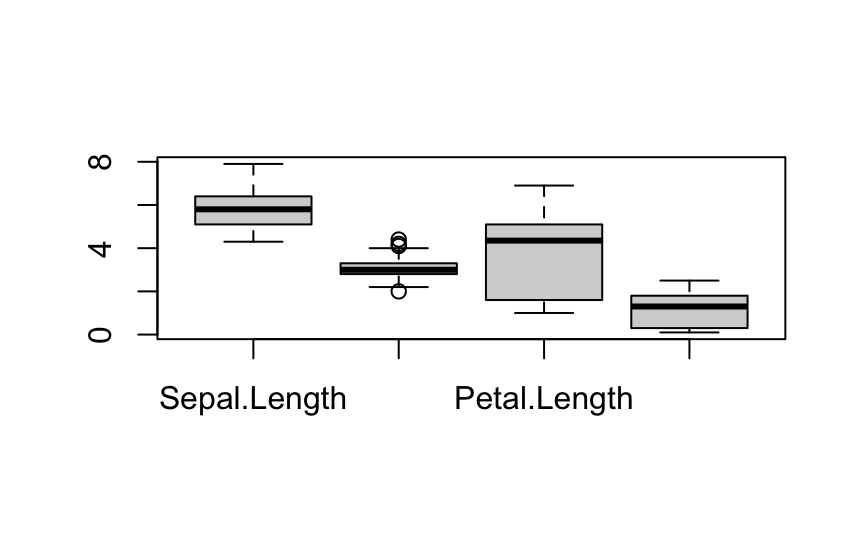

```r
# just a boxplot
boxplot(X[ ,1:4])
```

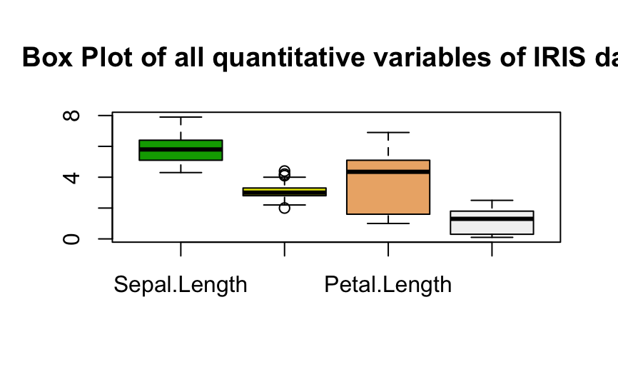

```r
# boxplot with a title and colors
boxplot(X[ ,1:4], main = "Box Plot of all quantitative variables of IRIS data", col = terrain.colors(4))
```

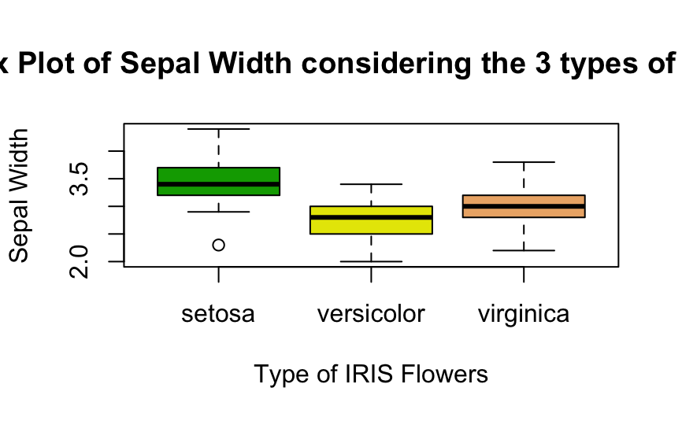

```r
boxplot(X$Sepal.Width ~ X$Species, main = "Box Plot of Sepal Width considering the 3 types of flowers", xlab = "Type of IRIS Flowers", ylab = "Sepal Width", col = terrain.colors(4))
```

The *tilde symbol* is obtained by:

- these doesn’t work [*]:
  - MAC: option + 5
  - WIN: ALT + 125/6
- these works [*]:
  - MAC: shift + button before no.1
  - WIN: shift + button before no.1

## [ 2.1. BONUS ]

The bold line is the **Median**, that is the value of the ordered distribution that leaves the same number of units above and below (or on left and right)

- **Q1** is the first quartile. Q1 leaves 25% of unirs on left and 75% on right.
- **Q3** is the third quartile. Q3 leaves 75% of units on left and 25% on right.
- Wishers, **without outliers** are, the min and max of distribution
- Wishers, **with outliers** are, Lmin = Q1-1.5*(Q3-Q1); Lsup = Q3+1.5*(Q3-Q1);

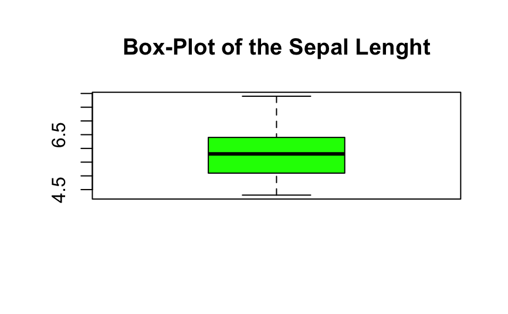

```r
boxplot(X$Sepal.Length, main = "Box-Plot of the Sepal Lenght", col = "green", horizontal = F)
```

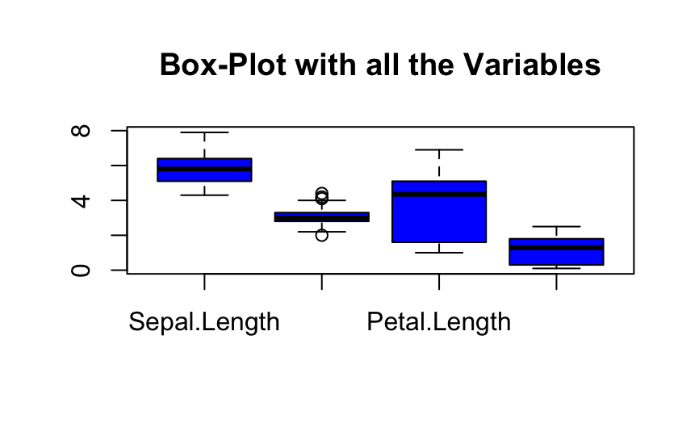

```r
boxplot(X[ ,1:4], main = "Box-Plot with all the Variables", col = "blue", horizontal = F)
```

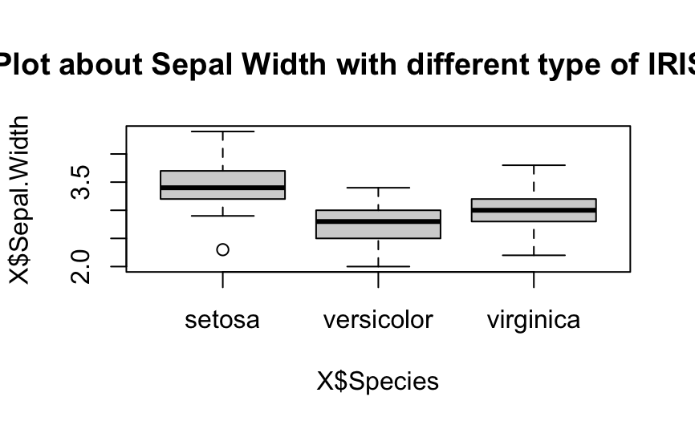

```r
boxplot(X$Sepal.Width ~ X$Species, main = "Box-Plot about Sepal Width with different type of IRIS Flowers")
```

# 2.2. Bar Plot

Bar Plot can be used for **Qualitative Data** and for **Categorized Quantitative Data**. The first step to create a Bar Plot is to generate a *Table of Frequency*.

```r
T <- table(X$Species)
T
```

```
    setosa versicolor  virginica
        50         50         50
```

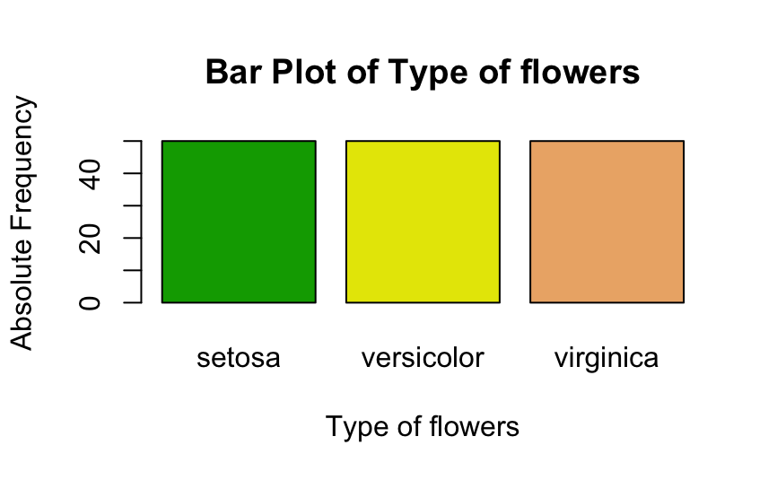

```r
barplot(T, main = "Bar Plot of Type of flowers", xlab = "Type of flowers", ylab = "Absolute Frequency", col = terrain.colors(4))
```

# 2.3. Pie Chart

It is based on the frequency table.

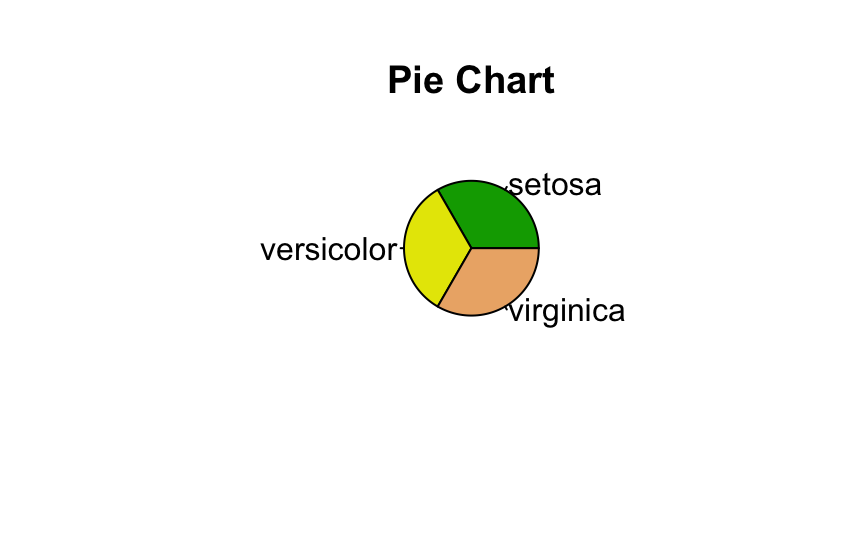

```r
pie(T, main = "Pie Chart", col = terrain.colors(4))
```

# 2.4. Histogram Chart

Histogram is a plot used only for **Quantitative Data**, it is based on a frequency tables in classes. The *R* function is called *hist* and the input is a simple distribution of a quantitative variable.

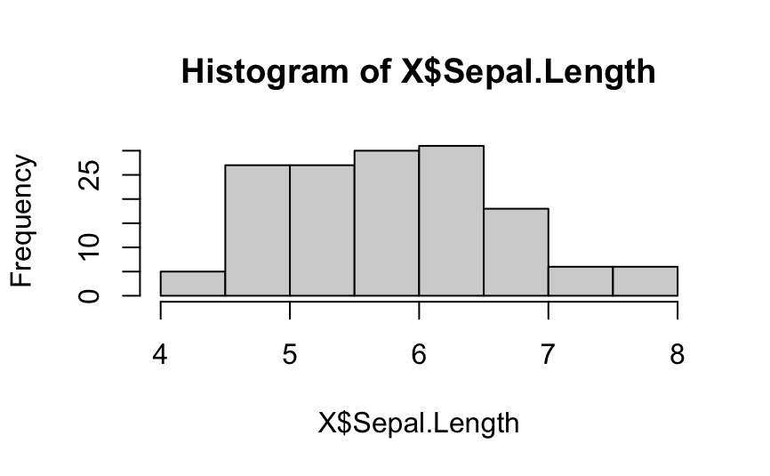

```r
hist(X$Sepal.Length)
```

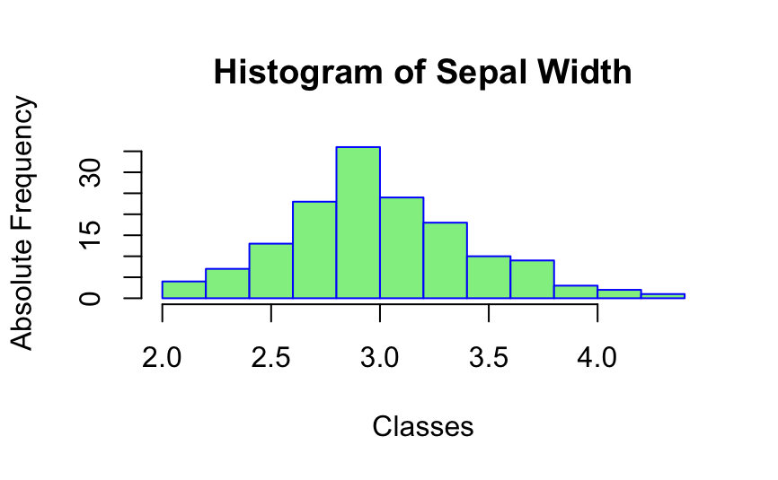

```r
hist(X$Sepal.Width, main = "Histogram of Sepal Width", xlab = "Classes", ylab = "Absolute Frequency", col = "lightgreen", border = "blue")
```

## [ 2.4. BONUS ]

he histogram can be used only for **quantitative variables**.

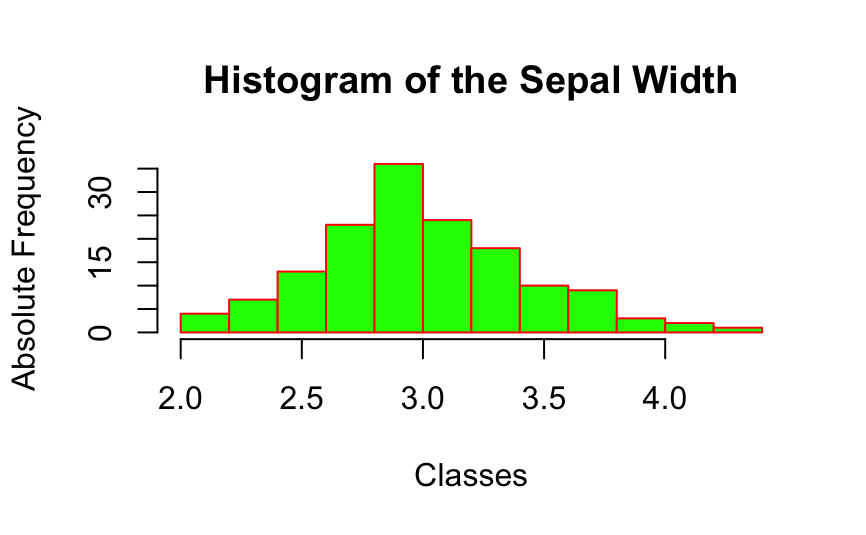

```r
hist(X$Sepal.Width, main = "Histogram of the Sepal Width", xlab = "Classes",
     ylab = "Absolute Frequency", col = "green", border = "red", breaks = 10)
```

In case of equally spaced (same size) classes we can report on the *Y* axis the Absolute Frequency or relative frequency. In case of classes with different sizes we have to report on *Y* axis the *density of frequency*. The formula is the following: $d_i = n_i/h_i$, where $n_i$ is the absolute frequency and $h_i$ is the size of the class.

# 3. Correlation Analysis

## 3.1. Correlation Plot

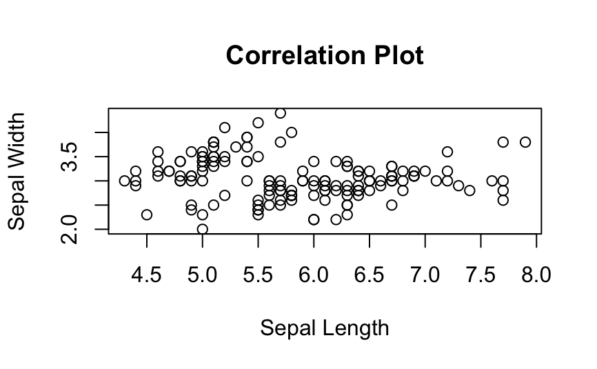

```r
plot(X$Sepal.Length, X$Sepal.Width, main = "Correlation Plot", xlab = "Sepal Length", ylab = "Sepal Width")
```

## [ 3.1. BONUS ]

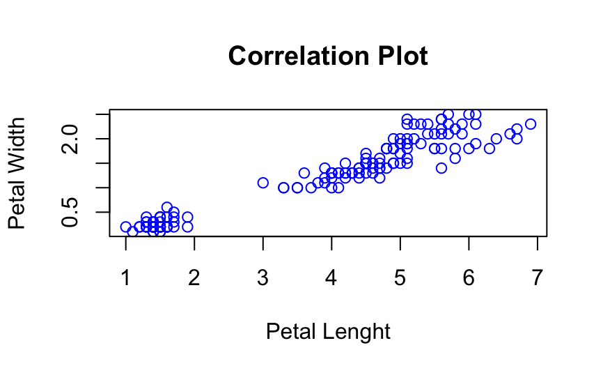

```r
plot(X$Petal.Length, X$Petal.Width, main = "Correlation Plot",
     xlab = "Petal Lenght", ylab = "Petal Width", col = "blue",
     pch = 1)
```

Plots with IRIS

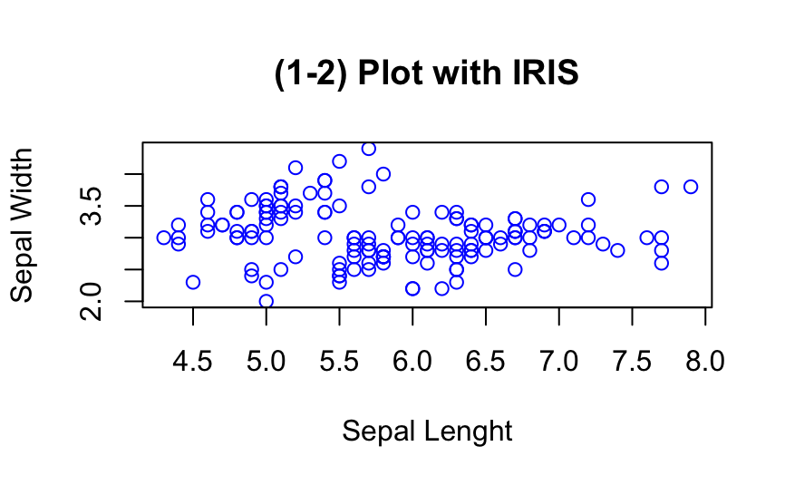

```r
plot(X$Sepal.Length, X$Sepal.Width, main = "(1-2) Plot with IRIS",
     xlab = "Sepal Lenght", ylab = "Sepal Width", col = "blue")
```

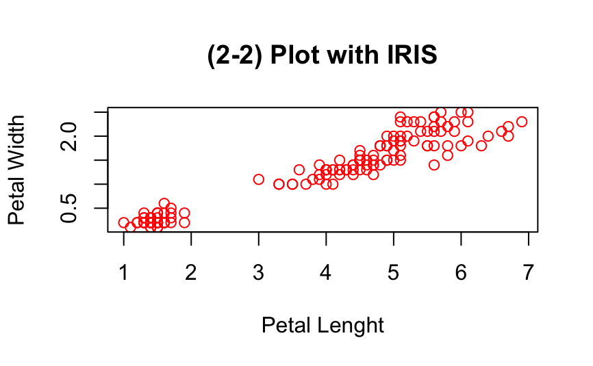

```r
plot(X$Petal.Length, X$Petal.Width, main = "(2-2) Plot with IRIS",
     xlab = "Petal Lenght", ylab = "Petal Width", col = "red")
```

## 3.2. Pair Plot

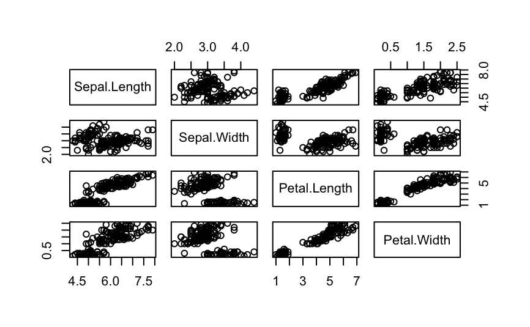

```r
pairs(X[ ,1:4])
```

The plots below the main diagonal are the same of the plot above the main diagonal. The reason is because the plot and the correlation index are symmetric.

```r
r <- cor(X[ ,1:2])
r <- round(r, 3)
r
```

```
             Sepal.Length Sepal.Width
Sepal.Length        1.000      -0.118
Sepal.Width        -0.118       1.000
```

```r
cor(X$Sepal.Length, X$Sepal.Width)
```

```
[1] -0.1175698
```

The range of correlation index is: *-1 <= r <= 1* The interpretation of the *Correlation Index* called **r** is following:

- 0.00 < |r| <= 0.25 *Low Correlation*
- 0.25 < |r| <= 0.50 *Medium-Low Correlation*
- 0.50 < |r| <= 0.75 *Medium-High Correlation*
- 0.75 < |r| <= 1.00 *High Correlation*
- 0 *No Correlation*
- 1 *Perfect Correlation*

The correlation between *Sepal Length* and *Sepal Width* is -0.118 and it is a low negative correlation.

# 4. Plots with GGPLOT Package

```r
install.packages("ggplot2")
```

```
Error in install.packages : Updating loaded packages
```

```r
library(ggplot2)
```

GGPLOTS has 3 main arguments:

- The first argument is the data: *ggplot(data = X)*. It creates an empty frame.
- The second argument is the geometry (type of plot): *geom_*. It adds a layer with the type of plot we want to show.
- The third argument is the aesthetic, to select the variables and the properties: *mapping = aes()*

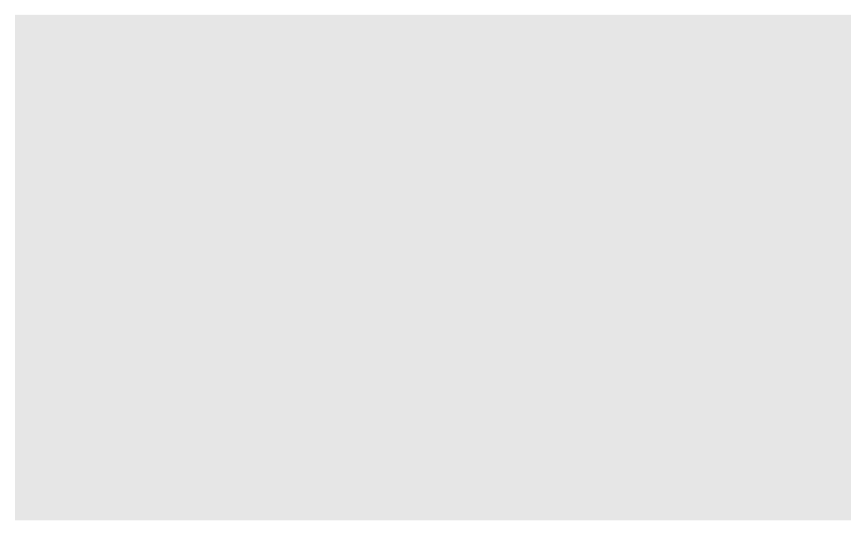

```r
# GGPLOT (example no 1)
ggplot(data = X[ ,1:2])
```

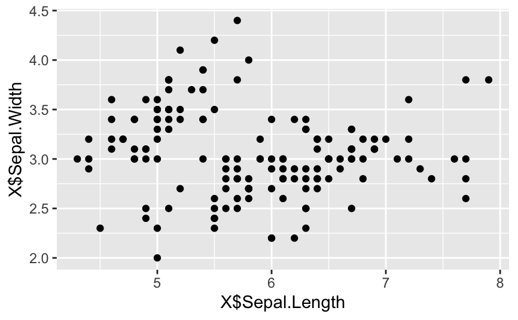

```r
# GGPLOT (example no 2.1)
ggplot(data = X[ ,1:2]) +
  geom_point(mapping = aes(X$Sepal.Length, X$Sepal.Width))
```

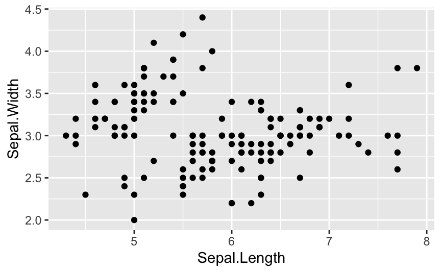

```r
# GGPLOT (example no 2.2)
ggplot(data = X[ ,1:2]) +
  geom_point(mapping = aes(Sepal.Length, Sepal.Width))
```

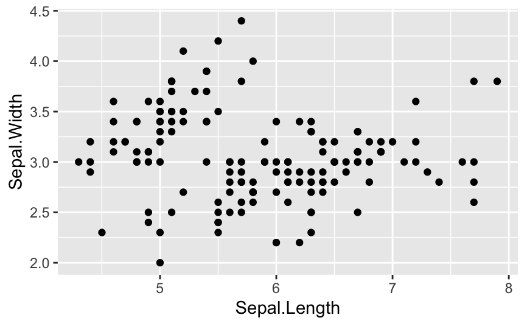

```r
# GGPLOT (example no 2.2)
ggplot(data = X) +
  geom_point(mapping = aes(Sepal.Length, Sepal.Width))
```

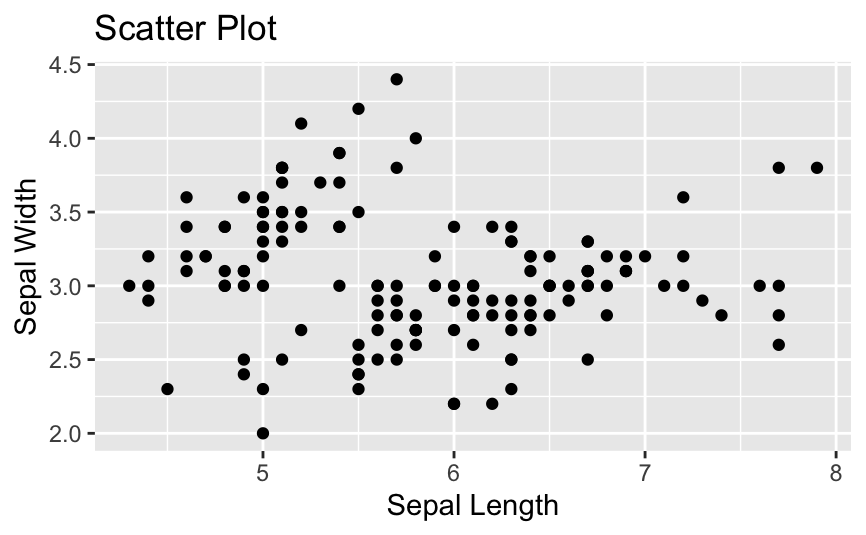

```r
# GGPLOT (example no 3)
ggplot(data = X) +
  geom_point(mapping = aes(Sepal.Length, Sepal.Width)) +
  ggtitle("Scatter Plot") + xlab("Sepal Length") + ylab("Sepal Width")
```

## 4.1. Correlation Plot (Scatter Plot) with colors

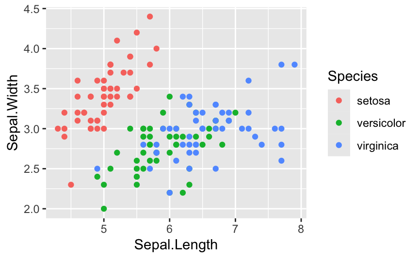

```r
ggplot(data = X) +
  geom_point(mapping = aes(Sepal.Length, Sepal.Width, color = Species))
```

## [ 4.1. BONUS ]

**STANDARD TEMPLATE IS:** ggplot(data = ) + (mapping = aes())

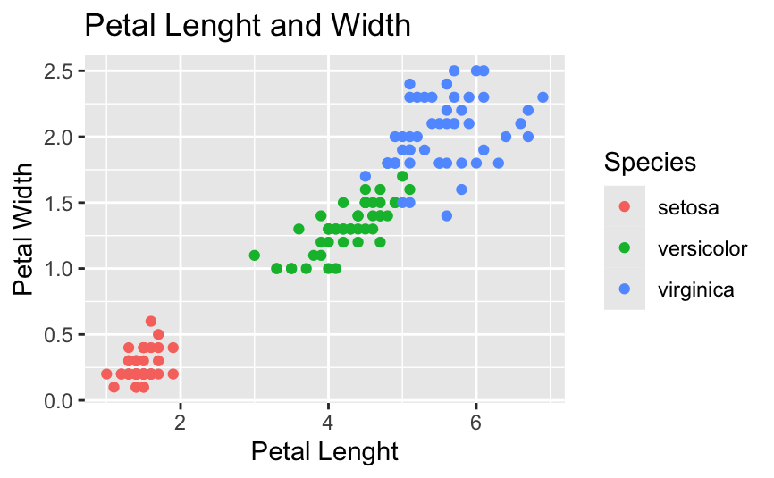

```r
# First Example
ggplot(data = X) +
  geom_point(mapping = aes(Petal.Length, Petal.Width, color = Species)) +
  ggtitle("Petal Lenght and Width") +
  xlab("Petal Lenght") + ylab("Petal Width")
```

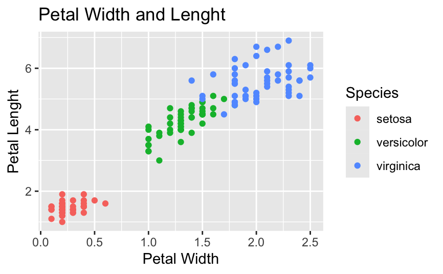

```r
# Second Example
ggplot(data = X, mapping = aes(Petal.Width, Petal.Length)) +
  geom_point(mapping = aes(color = Species)) +
  ggtitle("Petal Width and Lenght") +
  xlab("Petal Width") + ylab("Petal Lenght")
```